# Ok Cupid Capstone Project:

## Stage 2: Feature Engineering

## Load data and libraries:

### Recall from Stage 1:

- **"scaled_df"**:
  - Database with all essay answers parsed and cleaned
  - 'location' and 'speaks' columns prepared as lists
  - Continuous variables ('age', 'height', 'income') have outliers removed and are scaled between zero and one.

```python
scaled_df.shape
```

```
(58848, 28)
```

```
Example user profile in 'scaled_df':
```

|  | age | body_type | diet | drinks | drugs | education | essay0 | essay1 | essay2 | essay3 | ... | income | job | offspring | orientation | pets | religion | sex | smokes | speaks | city |
| --- | --- | --- | --- | --- | --- | --- | --- | --- | --- | --- | --- | --- | --- | --- | --- | --- | --- | --- | --- | --- | --- |
| 0 | 0.095238 | a little extra | strictly anything | socially | never | working on college/university | would love think kind intellectual either dumb... | currently working international agent freight ... | making people laugh ranting good salting findi... | way look six foot half asian half caucasian mu... | ... | 0.4212 | transportation | doesn’t have kids, but might want them | straight | likes dogs and likes cats | agnosticism and very serious about it | m | sometimes | ['english'] | south san francisco |

1 rows × 28 columns

## Target Feature Engineering:

```
Number of different education categories: 32
```

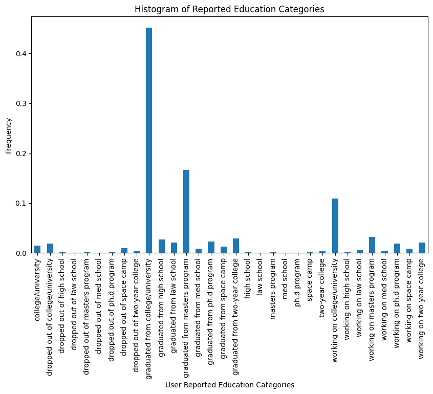

```
graduated from college/university    23615
graduated from masters program        8682
working on college/university         5693
working on masters program            1681
graduated from two-year college       1482
graduated from high school            1396
graduated from ph.d program           1210
graduated from law school             1085
working on two-year college           1065
working on ph.d program                981
dropped out of college/university      962
college/university                     781
graduated from space camp              646
dropped out of space camp              514
graduated from med school              440
working on space camp                  440
working on law school                  268
working on med school                  212
two-year college                       209
dropped out of two-year college        182
dropped out of masters program         135
masters program                        129
dropped out of ph.d program            119
dropped out of high school              98
high school                             95
working on high school                  87
space camp                              56
ph.d program                            23
law school                              19
dropped out of law school               16
dropped out of med school               11
med school                              11
Name: education, dtype: int64
32
```

### Education ordinal label rationale

|  | Current category label | New category label | Education level |
| --- | --- | --- | --- |
| 0 | graduated from masters program | postgrad | 4 |
| 1 | graduated from ph.d program | postgrad | 4 |
| 2 | graduated from law school | postgrad | 4 |
| 3 | graduated from med school | postgrad | 4 |
| 4 | working on ph.d program | postgrad | 4 |
| 5 | working on med school | postrad | 4 |
| 6 | med school | postgrad | 4 |
| 7 | law school | postgrad | 4 |
| 8 | working on law school | postgrad | 4 |
| 9 | masters program | postgrad | 4 |
| 10 | ph.d program | postgrad | 4 |
| 11 | college/university | bachelor | 3 |
| 12 | graduated from college/university | bachelor | 3 |
| 13 | working on masters program | bachelor | 3 |
| 14 | dropped out of law school | bachelor | 3 |
| 15 | dropped out of masters program | bachelor | 3 |
| 16 | dropped out of ph.d program | bachelor | 3 |
| 17 | dropped out of med school | bachelor | 3 |
| 18 | two-year college | post_highschool | 2 |
| 19 | graduated from two-year college | post_highschool | 2 |
| 20 | working on college/university | post_highschool | 2 |
| 21 | dropped out of two-year college | secondary | 1 |
| 22 | dropped out of college/university | secondary | 1 |
| 23 | working on two-year college | secondary | 1 |
| 24 | high school | secondary | 1 |
| 25 | graduated from high school | secondary | 1 |
| 26 | dropped out of high school | primary | 1 |
| 27 | working on high school | primary | 1 |
| 28 | working on space camp | unknown | 0 |
| 29 | graduated from space camp | unknown | 0 |
| 30 | dropped out of space camp | unknown | 0 |
| 31 | space camp | unknown | 0 |

### Distribution of ordinal scaled target values

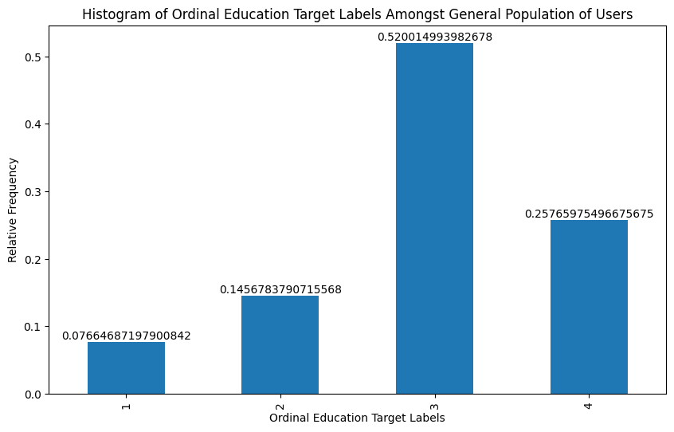

- The distribution of the target variable, "Ordinal education label", is still imbalanced after conversion from categorical descriptors to the 1-4 ordinal system.
- Choice of machine learning method used to create the Education Level Predictor is influenced by this imbalance. Whatever training method is chosen, it must be able to handle the error produced from the imbalance. Ensemble methods such as **Random Forest Classifiers** and **AdaBoost** may be usefull in this context.

### Outliers in 'income' column (revisited):

- The idea of outliers in the income column needs to revisited at this point. Now that we have transformed the education categories to ordinal labels, we can see if the distribution of the target variable (Education level) is different amongst high earners (i.e. \$500,000 or \$1,000,000 reported income) compared to the general population.

```python
#Null hypothesis: There is no difference in the distribution of the education levels amongst
#top 1% high earners compared to the general population:

#Test null hypothesis:
```

```
Chi-Squared Statistic: 12.0
P-value: 0.21330930508341653
```

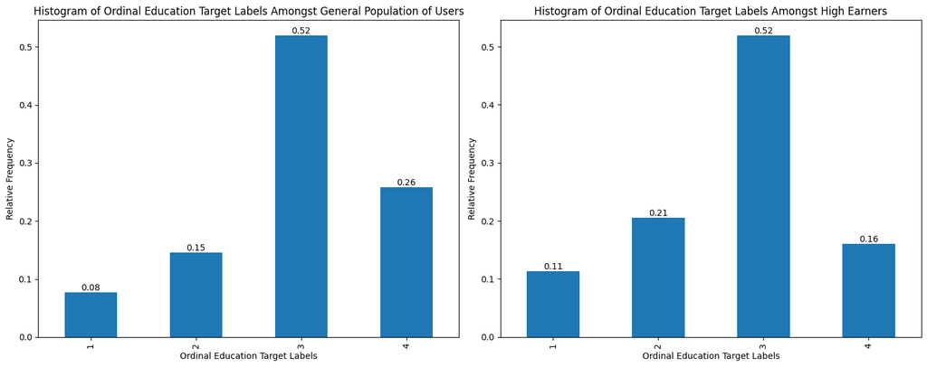

## Training Feature Engineering:

### NLP based features:

#### NLP based features - rationale:

- **The following feature set will be engineered from the post-html-parsing, pre-lemmatization essay answers:**
- - number of characters
  - number of words total
  - number of dictionary-words
  - number of punctuation
  - number of sentences
  - number of unique words
  - number of stop words
  - average dictionary-word length
  - average sentence length
  - ratio of acceptable/total words
  - ratio of stop words/total words

Before starting this section of the project, we need to consider a question:

- Is better to consider each of the essay question answers seperately (ie create NLP engineered feature columns and, later, Tf-IDF vectors for each answer a user provided)...

  *or*
- ...is it more informative to our model to consider the entire corpus of what the user ha written (ie create **one** set of NLP engineered feature columns and train Tf-IDF on the entire corpus of the 9 essay answer columns, producing one single sparse matrix for each user?

**Two Options:**

1. **Consider Each Essay Answer Separately**:
   - **Advantages**:
     - Captures the unique characteristics and vocabulary of each essay answer individually.
     - Allows the model to distinguish between the importance of terms within each essay answer.
   - **Considerations**:
     - Each essay answer is treated as an independent document, which may not fully capture relationships or patterns across multiple answers from the same user.
     - Increases the dimensionality of the feature space, which may lead to higher computational costs, especially if the dataset is large.
2. **Consider All Essay Answers Together**:
   - **Advantages**:
     - Creates a single TF-IDF and NLP feature set representation for each user, incorporating information from all essay answers.
     - May capture overall patterns or themes across multiple answers, providing a holistic view of the user's profile.
   - **Considerations**:
     - Assumes that all essay answers contribute equally to the user's profile, which may not always be the case.
     - The combined text may dilute the importance of individual answers, especially if some answers are more relevant to the prediction task than others.

**Why not do both?**

We will save the output from the two methods in feature columns of out training dataframe, to be loaded and experimented with during the model training section of the project.

```
Essay question features after NLP:
```

|  | essay0_character_count | essay0_words_total | essay0_real_words_count | essay0_real_word_ratio | essay0_punctuation_count | essay0_unique_words_count | essay0_stopwords_count | essay0_average_word_length | essay0_average_sentence_length | essay0_unique_words_ratio | essay0_stopwords_ratio | essay1_character_count | essay1_words_total | essay1_real_words_count | essay1_real_word_ratio | essay1_punctuation_count | essay1_unique_words_count | essay1_stopwords_count | essay1_average_word_length | essay1_average_sentence_length | essay1_unique_words_ratio | essay1_stopwords_ratio | essay2_character_count | essay2_words_total | essay2_real_words_count | essay2_real_word_ratio | essay2_punctuation_count | essay2_unique_words_count | essay2_stopwords_count | … |
| --- | --- | --- | --- | --- | --- | --- | --- | --- | --- | --- | --- | --- | --- | --- | --- | --- | --- | --- | --- | --- | --- | --- | --- | --- | --- | --- | --- | --- | --- | --- |
| 0 | 0.033411 | 0.041195 | 0.046347 | 0.975207 | 0.0 | 0.060515 | 0.0 | 0.047465 | 0.041195 | 0.841356 | 0.0 | 0.041602 | 0.042276 | 0.045614 | 0.962963 | 0.0 | 0.058691 | 0.0 | 0.075732 | 0.042276 | 1.000000 | 0.0 | 0.023569 | 0.013736 | 0.015110 | 1.000000 | 0.0 | 0.020942 | 0.0 | … |
| 1 | 0.037795 | 0.042568 | 0.045169 | 0.920000 | 0.0 | 0.063511 | 0.0 | 0.055568 | 0.042568 | 0.854515 | 0.0 | 0.085846 | 0.084553 | 0.089474 | 0.962264 | 0.0 | 0.112867 | 0.0 | 0.080541 | 0.084553 | 0.957547 | 0.0 | 0.087801 | 0.052198 | 0.052198 | 0.974359 | 0.0 | 0.094241 | 0.0 | … |
| 2 | 0.000851 | 0.001030 | 0.001571 | 1.000000 | 0.0 | 0.001797 | 0.0 | 0.037162 | 0.001030 | 1.000000 | 0.0 | 0.008144 | 0.008130 | 0.010526 | 1.000000 | 0.0 | 0.011287 | 0.0 | 0.067164 | 0.008130 | 1.000000 | 0.0 | 0.022015 | 0.010989 | 0.012363 | 1.000000 | 0.0 | 0.020942 | 0.0 | … |
| 3 | 0.006597 | 0.008582 | 0.009819 | 0.961538 | 0.0 | 0.014979 | 0.0 | 0.041580 | 0.008582 | 1.000000 | 0.0 | 0.005063 | 0.006504 | 0.008772 | 1.000000 | 0.0 | 0.002257 | 0.0 | 0.044776 | 0.006504 | 0.325000 | 0.0 | 0.017871 | 0.005495 | 0.004121 | 0.600000 | 0.0 | 0.010471 | 0.0 | … |
| 4 | 0.022558 | 0.027120 | 0.026709 | 0.850000 | 0.0 | 0.038346 | 0.0 | 0.049493 | 0.027120 | 0.810567 | 0.0 | 0.016289 | 0.013008 | 0.015789 | 1.000000 | 0.0 | 0.018059 | 0.0 | 0.096186 | 0.013008 | 1.000000 | 0.0 | 0.065009 | 0.052198 | 0.048077 | 0.897436 | 0.0 | 0.070681 | 0.0 | … |

```
Number of NLP feature columns engineered:

 121
```

### One Hot Encode (OHE) categorical columns:

- The following features were one hot encoded:

| These were... | ...one hot... | ...encoded... |
| --- | --- | --- |
| Ethnicity | Orientation | City |
| Speaks | Offspring | Job |
| Body Type | Religion | Pets |
| Diet | Smokes | Sex |
| Drinks | Drugs |  |

- OHE feature set adds 427 dimensions to the 121 engineered in the NLP section
- OHE and NLP feature sets are merged for a total dimensionality of 548.

```
Example of one hot encoded user profile:
```

|  | age | essay0 | essay1 | essay2 | essay3 | essay4 | essay5 | essay6 | essay7 | essay8 | essay9 | height | income | Education level | Education level 3 | ethnicity_asian | ethnicity_black | ethnicity_hispanic / latin | ethnicity_indian | ethnicity_middle eastern | ethnicity_native american | ethnicity_other | ethnicity_pacific islander | ethnicity_white | speaks_afrikaans | speaks_albanian | speaks_ancient greek | speaks_arabic | speaks_armenian | … |
| --- | --- | --- | --- | --- | --- | --- | --- | --- | --- | --- | --- | --- | --- | --- | --- | --- | --- | --- | --- | --- | --- | --- | --- | --- | --- | --- | --- | --- | --- | --- |
| 0 | 0.095238 | would love think kind intellectual either dumb... | currently working international agent freight ... | making people laugh ranting good salting findi... | way look six foot half asian half caucasian mu... | books absurdistan republic mice men book made ... | food water cell phone shelter | duality humorous things | trying find someone hang anything except club | new california looking someone wisper secrets | want swept feet tired norm want catch coffee b... | 0.782609 | 0.4212 | 3 | 1 | 1 | 0 | 0 | 0 | 0 | 0 | 0 | 0 | 1 | 0 | 0 | 0 | 0 | 0 | … |

#### Merge NLP and OHE feature sets:

```
Example user profile in NLP_ohe_features dataframe:
```

|  | age | essay0 | essay1 | essay2 | essay3 | essay4 | essay5 | essay6 | essay7 | essay8 | essay9 | height | income | Education level | Education level 3 | ethnicity_asian | ethnicity_black | ethnicity_hispanic / latin | ethnicity_indian | ethnicity_middle eastern | ethnicity_native american | ethnicity_other | ethnicity_pacific islander | ethnicity_white | speaks_afrikaans | speaks_albanian | speaks_ancient greek | speaks_arabic | speaks_armenian | … |
| --- | --- | --- | --- | --- | --- | --- | --- | --- | --- | --- | --- | --- | --- | --- | --- | --- | --- | --- | --- | --- | --- | --- | --- | --- | --- | --- | --- | --- | --- | --- |
| 0 | 0.095238 | would love think kind intellectual either dumb... | currently working international agent freight ... | making people laugh ranting good salting findi... | way look six foot half asian half caucasian mu... | books absurdistan republic mice men book made ... | food water cell phone shelter | duality humorous things | trying find someone hang anything except club | new california looking someone wisper secrets | want swept feet tired norm want catch coffee b... | 0.782609 | 0.4212 | 3 | 1 | 1 | 0 | 0 | 0 | 0 | 0 | 0 | 0 | 1 | 0 | 0 | 0 | 0 | 0 | … |

### Word Embedding Vectors

[figure not shown]

```python
#Strategy 1: Create a 100 dimension word embedding vector based on the entire
#corpus of **all** essay response for each user:

def wordvectorizeall(df):
    # Extract the text data from the DataFrame
    text_data = df[['essay0', 'essay1', 'essay2', 'essay3', 'essay4', 'essay5', 'essay6', 'essay7', 'essay8', 'essay9']].astype(str).apply(lambda x: ' '.join(x), axis=1)

    # Calculate TF-IDF scores
    tfidf_vectorizer = TfidfVectorizer()
    tfidf_matrix = tfidf_vectorizer.fit_transform(text_data)

    # Normalize TF-IDF matrix
    tfidf_matrix_normalized = normalize(tfidf_matrix, norm='l2')

    # Initialize and train Word2Vec model
    word2vec_model = Word2Vec(sentences=[doc.split() for doc in text_data], vector_size=100, window=5, min_count=1, sg=1)

    # Obtain word embeddings for each document weighted by TF-IDF scores
    word_embeddings = []
    for i, doc in enumerate(text_data):
        doc_words = doc.split()
        doc_embedding = []
        for word in doc_words:
            if word in word2vec_model.wv and word in tfidf_vectorizer.vocabulary_:
                # Multiply word vector by TF-IDF score
                word_vec = word2vec_model.wv[word] * tfidf_matrix_normalized[i, tfidf_vectorizer.vocabulary_[word]]
                doc_embedding.append(word_vec)
            else:
                # If word not found in either vocabulary, use zero vector
                word_vec = [0] * 100
                doc_embedding.append(word_vec)
        # Calculate document embedding as the mean of word embeddings
        if doc_embedding:
            doc_embedding = np.mean(doc_embedding, axis=0)
        else:
            # If no words from the document are found in vocabularies, use a zero vector
            doc_embedding = [0] * 100
        word_embeddings.append(doc_embedding)
    # Convert the word embeddings into a DataFrame
    word_embeddings_df = pd.DataFrame(word_embeddings)

    # Rename the columns of the word embeddings DataFrame for clarity
    num_dimensions = len(word_embeddings[0])
    word_embedding_columns = [f'embed_{i+1}' for i in range(num_dimensions)]
    word_embeddings_df.columns = word_embedding_columns

    # Merge the word_embeddings with the NLP and OHE engineered feature set
    NLP_OHE_wordvec_df = pd.concat([NLP_ohe_features, word_embeddings_df], axis=1)

    return NLP_OHE_wordvec_df
```

```python
#Strategy 2: Create a 100 dimension word embedding vector
#for **each** individual essay question, per user:

# Create list of columns to be processed
target_columns = [
        'essay0', 'essay1', 'essay2', 'essay3', 'essay4', 'essay5', 'essay6',
        'essay7', 'essay8', 'essay9']

def wordvectorizeeach(df, target_columns):

    global NLP_OHE_wordvec_df

    # Iterate process for each of the individual essay answer columns
    for column in target_columns:
        # Extract the text data from the DataFrame
        text_data = df[column].astype(str)

        # Calculate TF-IDF scores
        tfidf_vectorizer = TfidfVectorizer()
        tfidf_matrix = tfidf_vectorizer.fit_transform(text_data)

        # Normalize TF-IDF matrix
        tfidf_matrix_normalized = normalize(tfidf_matrix, norm='l2')

        # Initialize and train Word2Vec model
        word2vec_model = Word2Vec(sentences=[doc.split() for doc in text_data],
                                  vector_size=100,
                                  window=5,
                                  min_count=1,
                                  sg=1)

        # Obtain word embeddings for each document weighted by TF-IDF scores
        word_embeddings = []
        for i, doc in enumerate(text_data):
            doc_words = doc.split()
            doc_embedding = []
            for word in doc_words:
                if word in word2vec_model.wv and word in tfidf_vectorizer.vocabulary_:
                    # Multiply word vector by TF-IDF score
                    word_vec = word2vec_model.wv[word] * tfidf_matrix_normalized[i, tfidf_vectorizer.vocabulary_[word]]
                    doc_embedding.append(word_vec)
                else:
                    # If word not found in either vocabulary, use zero vector
                    word_vec = [0] * 100
                    doc_embedding.append(word_vec)

            # Calculate document embedding as the mean of word embeddings
            if doc_embedding:
                doc_embedding = np.mean(doc_embedding, axis=0)
            else:
                # If no words from the document are found in vocabularies, use a zero vector
                doc_embedding = [0] * 100

            word_embeddings.append(doc_embedding)


        # Convert the word embeddings into a DataFrame
        word_embeddings_df = pd.DataFrame(word_embeddings)

        # Rename the columns of the word embeddings DataFrame for clarity
        num_dimensions = len(word_embeddings[0])
        word_embedding_columns = [f'embed_{column}_{i+1}' for i in range(num_dimensions)]
        word_embeddings_df.columns = word_embedding_columns

        # Merge the word_embeddings with the NLP, OHE, and word embeddings based on the "each" strategy
        NLP_OHE_wordvec_df = pd.concat([NLP_OHE_wordvec_df, word_embeddings_df], axis=1)

        #Drop the actual text essay answers. We've juiced them down their last drop!:
        NLP_OHE_wordvec_df = NLP_OHE_wordvec_df.drop(NLP_OHE_wordvec_df.columns[1:11], axis=1)

    return NLP_OHE_wordvec_df

#NLP_OHE_wordvec_df = wordvectorizeeach(NLP_OHE_wordvec_df, target_columns)
```

```
Example user profile in NLP_OHE_wordvec_df dataframe:
```

|  | age | height | income | Education level | Education level 3 | ethnicity_asian | ethnicity_black | ethnicity_hispanic / latin | ethnicity_indian | ethnicity_middle eastern | ethnicity_native american | ethnicity_other | ethnicity_pacific islander | ethnicity_white | speaks_afrikaans | speaks_albanian | speaks_ancient greek | speaks_arabic | speaks_armenian | speaks_basque | speaks_belarusan | speaks_bengali | speaks_breton | speaks_bulgarian | speaks_c++ | speaks_catalan | speaks_cebuano | speaks_chechen | speaks_chinese | … |
| --- | --- | --- | --- | --- | --- | --- | --- | --- | --- | --- | --- | --- | --- | --- | --- | --- | --- | --- | --- | --- | --- | --- | --- | --- | --- | --- | --- | --- | --- | --- |
| 0 | 0.095238 | 0.782609 | 0.4212 | 2 | 1 | 1 | 0 | 0 | 0 | 0 | 0 | 0 | 0 | 1 | 0 | 0 | 0 | 0 | 0 | 0 | 0 | 0 | 0 | 0 | 0 | 0 | 0 | 0 | 0 | … |

### Undersampling overrepresented target classes:

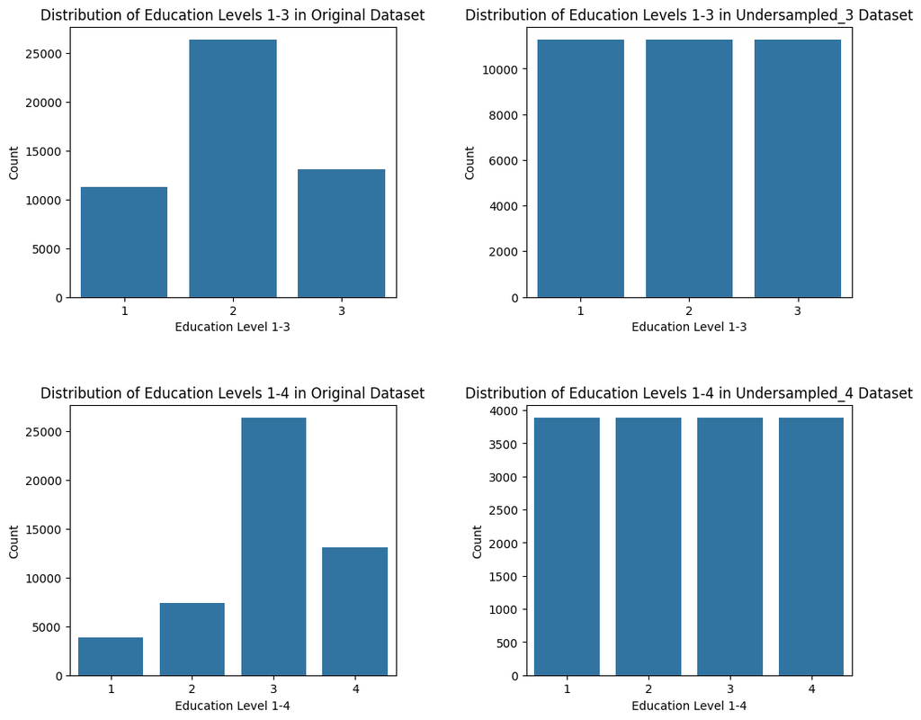

### Separate labels from feature set:

```python
#Splitting off feature set for the undersampled_3 dataset:
X3 = undersampled_3_df.drop(['Education level','Education level 3'], axis = 1)

#Splitting off feature set for the undersampled_4 dataset:
X4 = undersampled_4_df.drop(['Education level','Education level 3'], axis = 1)


#Label set using 1-3 Education Scale:
y3 = undersampled_3_df['Education level 3']

#Label set using 1-4 Education Scale:
y4 = undersampled_4_df['Education level']
```

## Train, test, split of datasets:

```python
#Train test split for 1-3 Education level datasset:
X3_train, X3_test, y3_train, y3_test = train_test_split(X3,
                                                        y3,
                                                        test_size=0.2,
                                                        random_state=42)

#Train test split for 1-4 Education level datasset:
X4_train, X4_test, y4_train, y4_test = train_test_split(X4,
                                                        y4,
                                                        test_size=0.2,
                                                        random_state=42)

#Convert all y datasets to be a 1D array (instead of a pd.series 2D object):
y3_train = y3_train.ravel()
y3_test = y3_test.ravel()
y4_train = y4_train.ravel()
y4_test = y4_test.ravel()
```

## Principal Component Analysis:

- Our dataframes currently have very large feature sets with 1636 feature dimensions.
- PCA should help to reduce this and make training of our models more efficient.
- Sacrifices interpretability

### Implement PCA on 1-3 Education Level DataFrame:

#### Determine number of pricipal axes to keep for the X3_train dataset - Scree Plot:

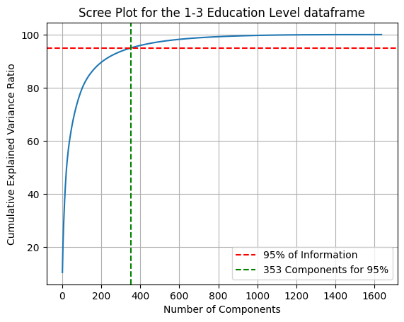

- Scree plotting indicates that we can use PCA to reduce the number of features in the 1-3 Education Level dataframe from 1636 to 353, while still retaining 95% of the information contained in the original. This will help with the computational intensity of training our models.

#### Fit-transform the 1-3 Educational Level Dataframe to optimal number of principal axes:

```python
# # Get principal components with 353 features and fit-transform as 'X3_train_pca' array:
# pca_1 = PCA(n_components=353)
# X3_train_pca = pca_1.fit_transform(X3_train)

# #Transform the X3_test subset with the pca_1 object, trained on X3_train above:
# X3_test_pca = pca_1.transform(X3_test)
```

```python
# #Save X3_train_pca, X3_test_pca, X4_train_pca, and X4_test_pca as arrays to be accessed when training:
# np.save('X3_train_pca.npy', X3_train_pca)
# np.save('X3_test_pca.npy', X3_test_pca)
```

### Implement PCA on the 1-4 Education Level DataFrame:

#### Determine number of principal axes to keep for the 1-4 Education Level DataFrame - Scree Plot:

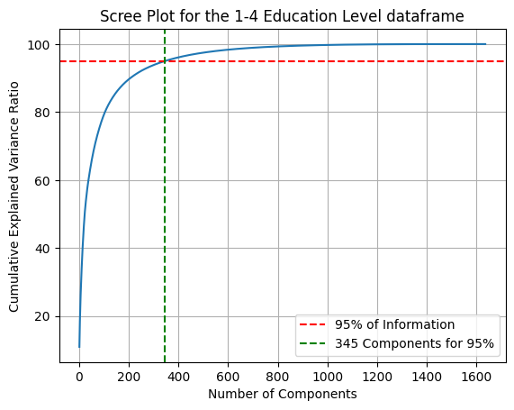

- Scree plotting indicates that we can use PCA to reduce the number of features in the 'each' dataframe from 1636 to 345, while still retaining 95% of the information contained in the original. This will help with the computational intensity of training our models.

```
 Example: 1-4 Education Level training subset after PCA:
```

|  | 0 | 1 | 2 | 3 | 4 | 5 | 6 | 7 | 8 | 9 | 10 | 11 | 12 | 13 | 14 | 15 | 16 | 17 | 18 | 19 | 20 | 21 | 22 | 23 | 24 | 25 | 26 | 27 | 28 | … |
| --- | --- | --- | --- | --- | --- | --- | --- | --- | --- | --- | --- | --- | --- | --- | --- | --- | --- | --- | --- | --- | --- | --- | --- | --- | --- | --- | --- | --- | --- | --- |
| 0 | -0.612957 | -0.574003 | -0.826604 | 0.560155 | -0.402855 | 0.212333 | 0.224001 | -0.052038 | 0.345992 | 0.306962 | -0.340286 | -0.505290 | -0.481091 | 0.346426 | 1.027398 | 0.669222 | 0.736559 | -0.820441 | 0.118281 | 0.155565 | -0.258142 | -0.115530 | 0.289221 | -0.710398 | 0.838427 | 0.216113 | 0.234119 | 0.272289 | 0.111347 | … |
| 1 | -0.253160 | -1.175870 | 0.326753 | -0.063034 | 0.552934 | 0.101276 | -0.052193 | 0.221880 | 0.080944 | -0.216818 | -0.252386 | -0.425342 | 0.204326 | -0.445397 | 0.168897 | -0.270367 | 0.612385 | -0.690369 | 0.010519 | 0.442091 | -0.828309 | 0.521907 | -0.389011 | -0.000342 | -0.705998 | -0.214522 | 0.019484 | 0.042392 | -0.016725 | … |
| 2 | -0.337252 | -0.246104 | 0.750551 | -0.343386 | -0.074743 | 0.020796 | -0.090675 | -0.863759 | -0.586477 | -0.062448 | -0.116840 | -0.134634 | 0.329513 | 0.846555 | -0.031487 | 0.516406 | -0.190093 | -0.360256 | -0.597373 | -0.488232 | -0.468667 | -0.009519 | 0.014408 | -0.252603 | -0.131650 | 0.634988 | -0.445753 | -0.258651 | -0.314248 | … |
| 3 | -1.185509 | -0.287369 | -0.112428 | 1.337338 | 1.062554 | 0.634138 | -0.388376 | 0.108922 | 0.214605 | -0.153726 | -0.918291 | -0.422373 | -0.580152 | 0.532348 | 0.142567 | 0.574956 | -0.008426 | 0.568231 | -0.044887 | -0.353867 | -0.059899 | -0.124703 | 0.070522 | -0.133275 | 0.725320 | 0.035263 | -0.190669 | -0.353843 | -0.192738 | … |
| 4 | 2.432574 | 0.127647 | 0.640321 | 0.022061 | 0.579836 | -0.239595 | 0.483265 | -0.305441 | 0.960155 | 0.526500 | 0.289005 | 0.854290 | -0.366535 | -0.923519 | -0.810144 | 0.410335 | 0.108783 | 0.358293 | 0.202077 | -1.113778 | -0.220868 | -0.067468 | -0.337199 | -0.037118 | 0.180122 | 0.152699 | 0.389672 | -0.513373 | -0.034551 | … |
| ... | ... | ... | ... | ... | ... | ... | ... | ... | ... | ... | ... | ... | ... | ... | ... | ... | ... | ... | ... | ... | ... | ... | ... | ... | ... | ... | ... | ... | ... | … |
| 12426 | -0.540613 | -0.506990 | -0.644135 | 0.552613 | 1.280718 | 0.157033 | -0.717870 | -0.292297 | -0.361385 | -0.154471 | -0.021899 | -0.015480 | -0.057945 | -0.201844 | -0.181715 | -0.270767 | -0.036347 | 0.802656 | -0.380245 | 0.041277 | 0.302412 | -0.240631 | 0.489380 | -0.009496 | -0.693091 | 0.033312 | 0.195770 | -0.153356 | -0.015260 | … |
| 12427 | -0.503323 | 0.012431 | 0.512646 | -0.057775 | -0.406090 | 0.233212 | 0.441672 | -0.811191 | -0.166490 | 1.128108 | 0.222300 | -0.369980 | -0.494386 | -0.384833 | 0.970517 | 1.060246 | -0.725315 | 0.449531 | 0.582245 | 1.639864 | -0.326258 | -0.077415 | 0.263740 | -0.736315 | -0.131744 | -0.515686 | -0.147369 | -0.133644 | 0.016379 | … |
| 12428 | -1.686029 | 0.711835 | 1.732804 | 1.136286 | 1.444179 | 0.658695 | 0.914981 | -0.318344 | -0.691538 | -0.654791 | 1.019300 | 0.102117 | -0.631144 | -0.658806 | -0.254734 | 0.333150 | -0.627352 | 0.204548 | 0.123931 | 0.198192 | -0.224023 | -0.790742 | 0.267322 | 0.700149 | 0.015336 | 0.295874 | 0.291200 | -0.147163 | 0.293244 | … |
| 12429 | 4.336867 | 0.994150 | 0.599998 | 0.553386 | 0.407484 | 0.740940 | -0.858784 | -0.476014 | 0.162306 | -0.237925 | -0.263254 | 0.727483 | 0.507748 | -0.004229 | 0.970684 | -0.322449 | -0.004490 | -0.818968 | -0.076899 | 0.427978 | -0.461153 | -0.366714 | 0.856716 | -0.035862 | -0.544944 | -0.014805 | 0.274912 | 0.024302 | -0.032064 | … |
| 12430 | 0.320241 | -0.278167 | -1.325472 | -0.442499 | -0.048540 | -0.494208 | 0.141338 | -0.933996 | 0.771670 | 0.293711 | 0.446714 | 0.002214 | 0.111099 | -0.160124 | 0.372454 | -0.507197 | 0.831245 | -0.698974 | 0.486071 | 0.573263 | 0.278638 | 0.590149 | -0.429784 | 0.708970 | -0.104069 | 0.011641 | 0.171658 | 0.106764 | -0.176688 | … |

12431 rows × 346 columns